# Bayesian Logistic Analysis

[Chenjia Li]

Due: Wednesday, 12/14

```r
# Load packages
library(dplyr)
library(ggplot2)
library(rstanarm)
library(bayesplot)
library(bayesrules)
library(tidyverse)
library(tidybayes)
library(broom.mixed)
```

## 1. Data Explanation and Data Wrangling

#### a) Description of Dataset and Purpose of my Discovery

In Social Network Purchase dataset, there are predictors such as Age and EstimatedSalary which can be used to build a logistic regression for binary response variable Puchased (either purchased 1 or not purchased 0).

DataSource: https://www.kaggle.com/datasets/dragonheir/logistic-regression, ANANYA NAYAN · 2017

#### b)Dataset Overview

```r
#Access dataset
data1 <- read.csv("sna.csv")

#First 10 row of the dataset
head(data1,10)
```

|  | User.ID | Gender | Age | EstimatedSalary | Purchased |
| --- | --- | --- | --- | --- | --- |
| 1 | 15624510 | Male | 19 | 19000 | 0 |
| 2 | 15810944 | Male | 35 | 20000 | 0 |
| 3 | 15668575 | Female | 26 | 43000 | 0 |
| 4 | 15603246 | Female | 27 | 57000 | 0 |
| 5 | 15804002 | Male | 19 | 76000 | 0 |
| 6 | 15728773 | Male | 27 | 58000 | 0 |
| 7 | 15598044 | Female | 27 | 84000 | 0 |
| 8 | 15694829 | Female | 32 | 150000 | 1 |
| 9 | 15600575 | Male | 25 | 33000 | 0 |
| 10 | 15727311 | Female | 35 | 65000 | 0 |

```r
#Response and Predictor names
attributes(data1)$names
```

```
[1] "User.ID"         "Gender"          "Age"             "EstimatedSalary" "Purchased"
```

```r
#Use school to do categorical regression
unique(data1$Gender)
```

```
[1] "Male"   "Female"
```

#### c)Data Wrangling

```r
data1 <- data1 %>%
  select(-User.ID)

data1
```

| Gender | Age | EstimatedSalary | Purchased |
| --- | --- | --- | --- |
| Male | 19 | 19000 | 0 |
| Male | 35 | 20000 | 0 |
| Female | 26 | 43000 | 0 |
| Female | 27 | 57000 | 0 |
| Male | 19 | 76000 | 0 |
| Male | 27 | 58000 | 0 |
| Female | 27 | 84000 | 0 |
| Female | 32 | 150000 | 1 |
| Male | 25 | 33000 | 0 |
| Female | 35 | 65000 | 0 |

[output cut: 390 more lines]

#### d) plot the dataset

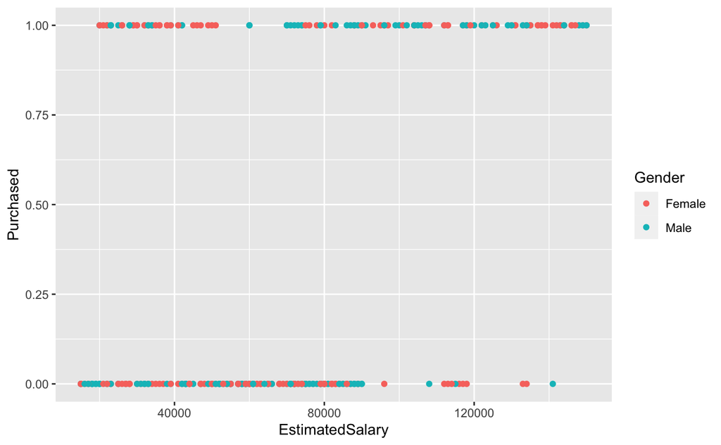

```r
#Binary response variable puchase = 1) 1 purchased 2) 0 not purchased
#As a result, we should use binomial distribution to build a logistic regression model for predicting the purchase
ggplot(data1, aes(x = EstimatedSalary, y = Purchased, color = Gender)) +
  geom_point()
```

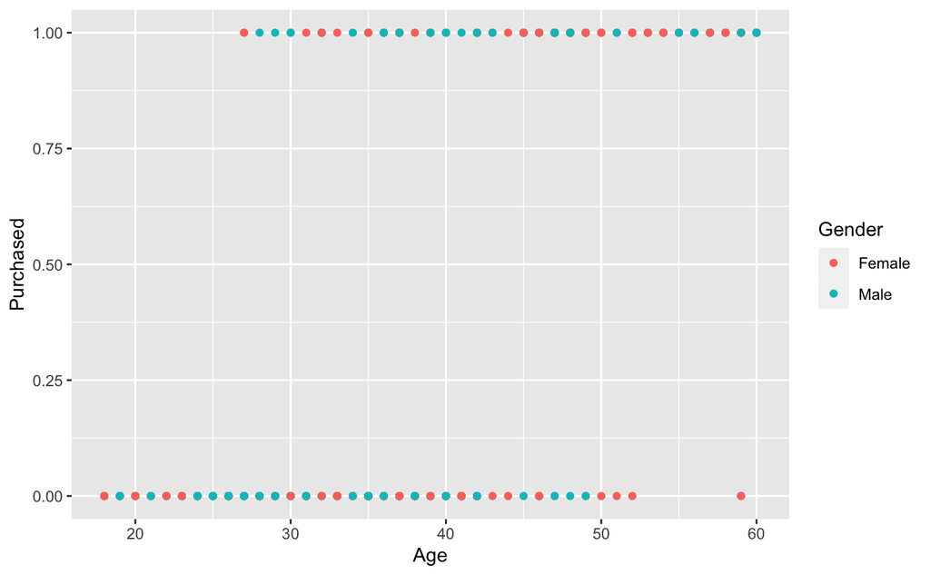

```r
ggplot(data1, aes(x = Age, y = Purchased, color = Gender)) +
  geom_point()
```

## 2. Build Model for logsitic regression

My prior understanding about the coefficients of predictors are normally distributed and have the following properties: 1) centered intercept:
$$\beta_{0c} \sim N(-1.25 ,
0.3)$$
which means Our prior understanding is
$$\pi \approx log(\frac{\pi}{1-\pi} =
log(\frac{0.18}{1-0.18} \approx -1.5)$$
and log odds varying between
$$(\frac{e^{-1.55}}{1+e^{-1.55}},\frac{e^{-0.95}}{1+e^{-0.95}})
= (0.175,0.279)$$

2. The salary coefficient (slope):
   $$\beta_1
   \sim N(0.003,0.0015)$$
   , for every 1 unit increase in salary, the log odds of purchase increase between
   $$(e^{0},e^{0.006}) \approx (1,1.006)$$

Then we can use above information to build our model

```r
purchase_model_prior <- stan_glm(Purchased ~ EstimatedSalary,
  data = data1, family = binomial,
  prior_intercept = normal(-1.25, 0.3),
  prior = normal(0.003, 0.0015, autoscale = T),
  chains = 4, iter = 5000*2, seed = 12375,
  prior_PD = TRUE)
purchase_model_prior2 <- stan_glm(Purchased ~ Age,
  data = data1, family = binomial,
  prior_intercept = normal(-1.25, 0.3),
  prior = normal(0.06, 0.03, autoscale = T),
  chains = 4, iter = 5000*2, seed = 12375,
  prior_PD = TRUE)
```

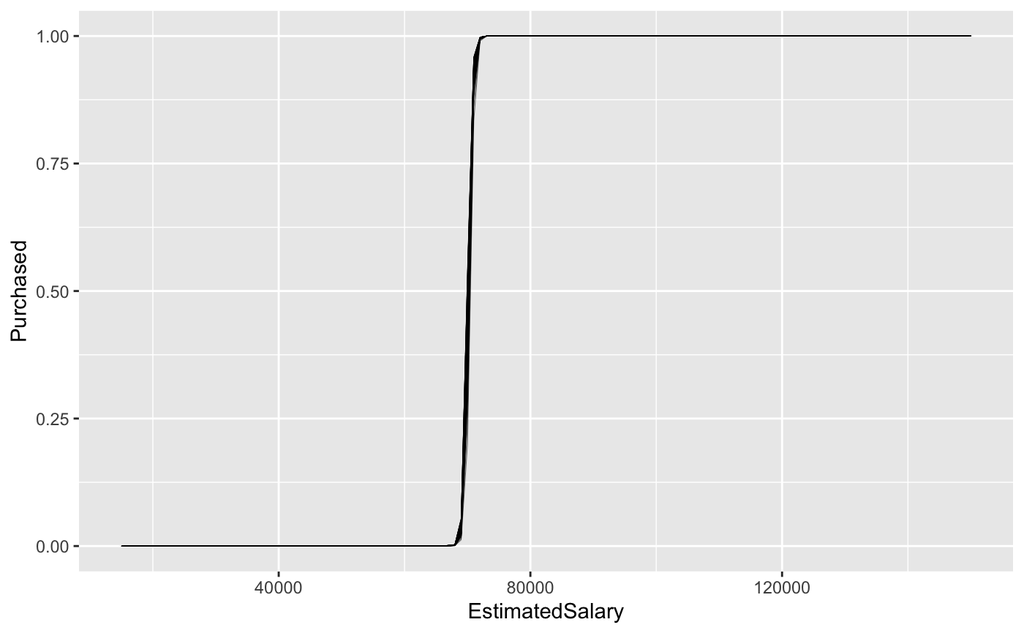

```r
data1 %>%
  add_fitted_draws(purchase_model_prior, n = 100) %>%
  ggplot(aes(x = EstimatedSalary, y = Purchased)) +
  geom_line(aes(y = .value, group = .draw), size = 0.1)
```

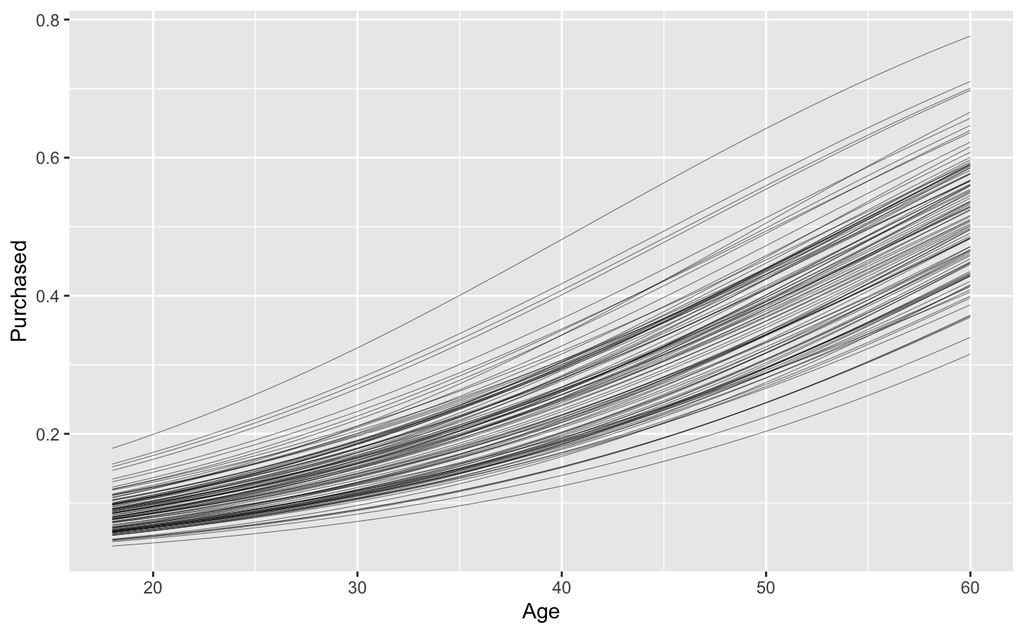

```r
data1 %>%
  add_fitted_draws(purchase_model_prior2, n = 100) %>%
  ggplot(aes(x = Age, y = Purchased)) +
  geom_line(aes(y = .value, group = .draw), size = 0.1)
```

```r
purchase_model_1 <- update(purchase_model_prior, prior_PD = FALSE)
purchase_model_2 <- update(purchase_model_prior2, prior_PD = FALSE)
```

## 4. Model Diagnostics

#### a) Diagnostics Plot

Based on the Trace plot, we see 1. Exhibit no discernible trends. 2. It Has a stable mean across the iterations. 3. It Has a stable variance across the iterations. 4. I Look similar to a bunch of white noise.

Based on the density plot, it is pretty close to normally disributed and similar shape for each chain.

For the Autocorrelation plot, after several lags, it is very obvious to see that the correlation becomes 0. All the above states the model is good to use.

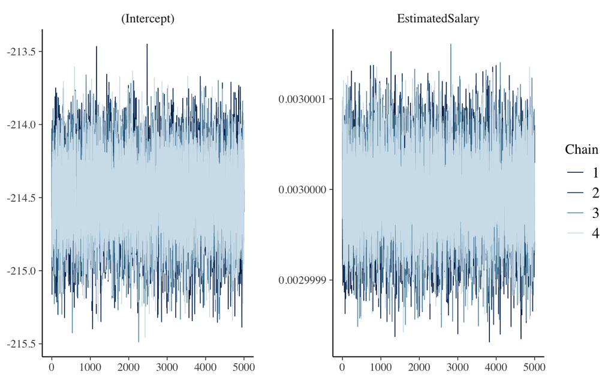

```r
mcmc_trace(purchase_model_1)
```

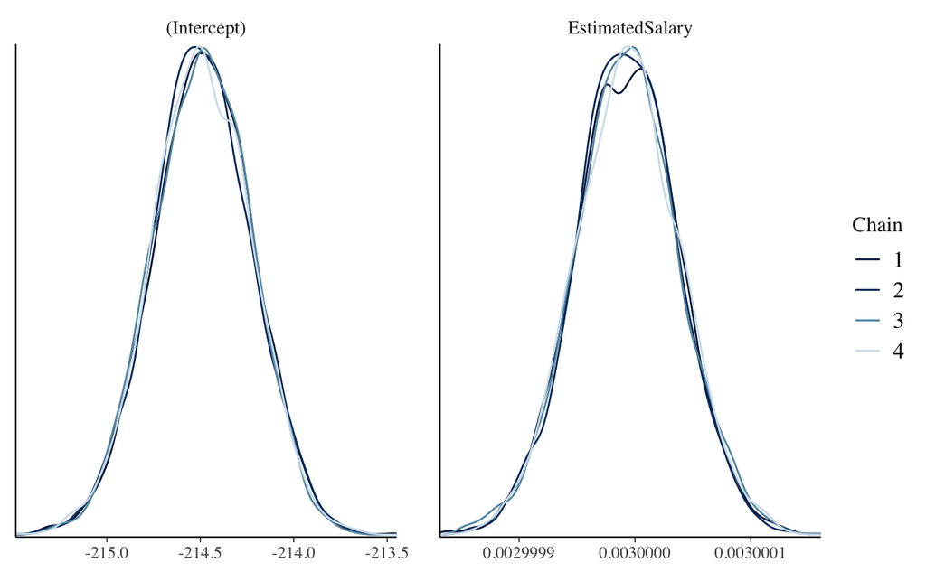

```r
mcmc_dens_overlay(purchase_model_1)
```

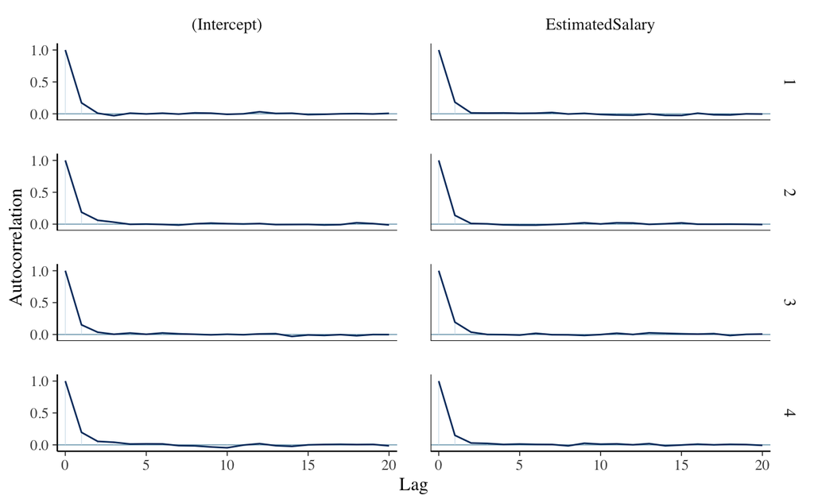

```r
mcmc_acf(purchase_model_1)
```

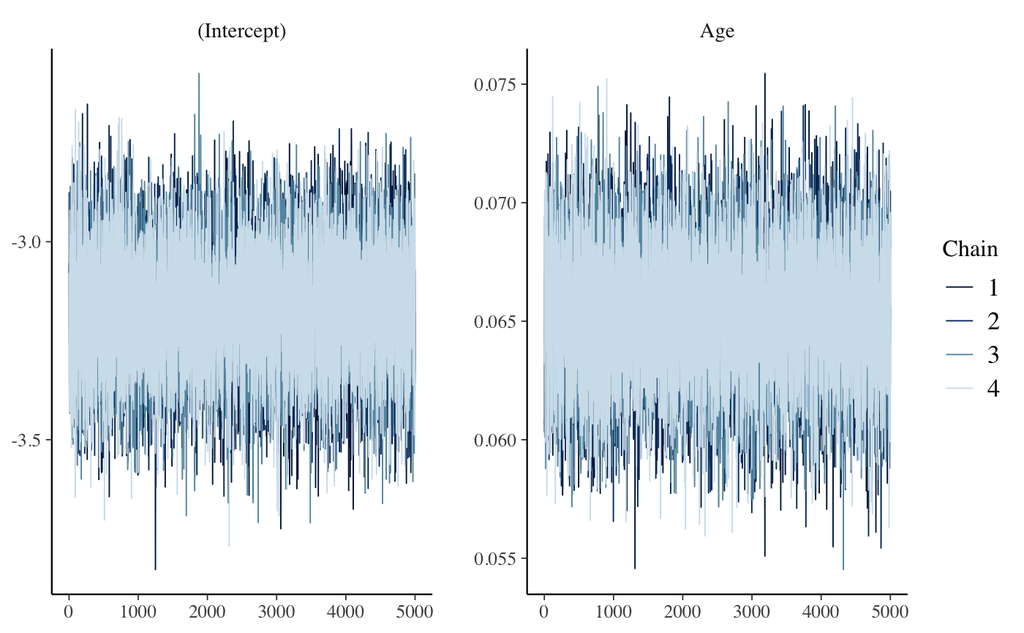

```r
mcmc_trace(purchase_model_2)
```

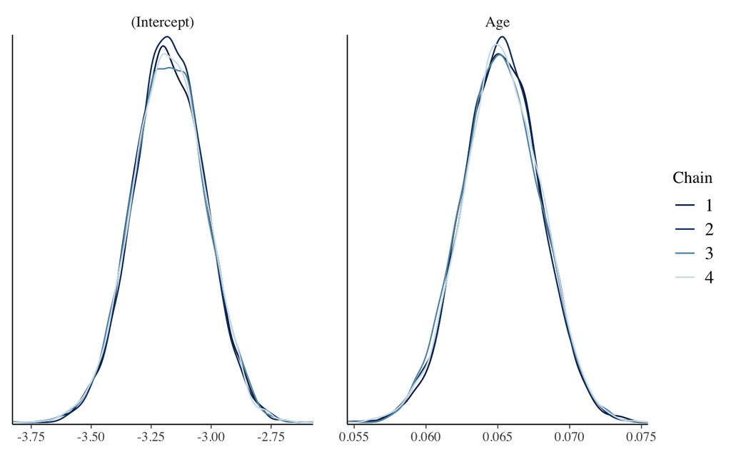

```r
mcmc_dens_overlay(purchase_model_2)
```

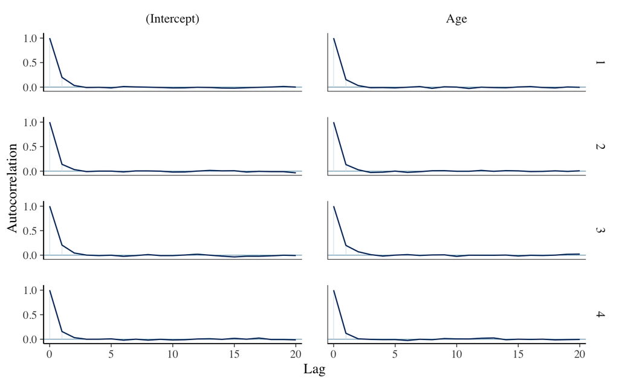

```r
mcmc_acf(purchase_model_2)
```

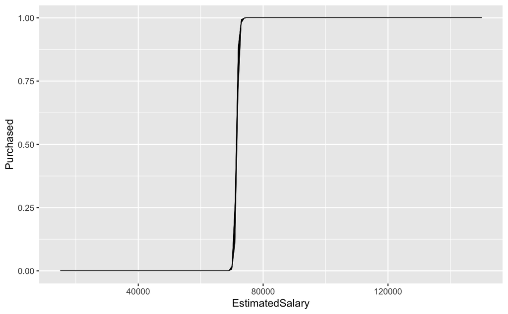

```r
data1 %>%
  add_fitted_draws(purchase_model_1, n = 100) %>%
  ggplot(aes(x = EstimatedSalary, y = Purchased)) +
  geom_line(aes(y = .value, group = .draw), size = 0.1)
```

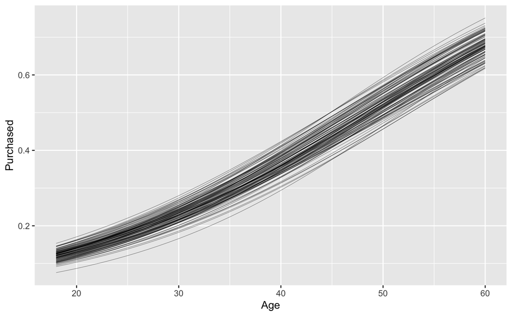

```r
data1 %>%
  add_fitted_draws(purchase_model_2, n = 100) %>%
  ggplot(aes(x = Age, y = Purchased)) +
  geom_line(aes(y = .value, group = .draw), size = 0.1)
```

#### b) The neff_Ratio and rhat

```r
neff_ratio(purchase_model_1)
```

```
    (Intercept) EstimatedSalary
        0.66630         0.70935
```

```r
rhat(purchase_model_1)
```

```
    (Intercept) EstimatedSalary
       1.000020        1.000218
```

```r
neff_ratio(purchase_model_2)
```

```
(Intercept)         Age
    0.70705     0.73665
```

```r
rhat(purchase_model_2)
```

```
(Intercept)         Age
  0.9998522   0.9999656
```

## 5. Model Analysis

Intervals for predictor coefficient

```r
posterior_interval(purchase_model_1, prob = 0.80)
```

```
                          10%           90%
(Intercept)     -2.148251e+02 -2.141487e+02
EstimatedSalary  2.999937e-03  3.000051e-03
```

```r
posterior_interval(purchase_model_2, prob = 0.80)
```

```
                    10%         90%
(Intercept) -3.36736084 -2.98016878
Age          0.06175988  0.06881609
```

## 6. Posterior predictions of binary outcome

It is Reasonable to classify at 72300 Salary level, it is better to say they are most likely to purchase the product. For the Age at 35, they are not likely to buy the product

```r
binary_prediction_Salary <- posterior_predict(purchase_model_1, newdata = data.frame(EstimatedSalary = 72300))
table(binary_prediction_Salary)
```

```
binary_prediction_Salary
    0     1
 1598 18402
```

```r
binary_prediction_Age <- posterior_predict(purchase_model_2, newdata = data.frame(Age = 35))
table(binary_prediction_Age)
```

```
binary_prediction_Age
    0     1
14146  5854
```

```r
classification_summary(model = purchase_model_1, data = data1, cutoff = 0.5)
```

```
$confusion_matrix
 y   0  1
 0 162 95
 1  50 93

$accuracy_rates
```

| sensitivity | 0.6503497 |
| --- | --- |
| specificity | 0.6303502 |
| overall_accuracy | 0.6375000 |

```r
classification_summary(model = purchase_model_1, data = data1, cutoff = 0.1)
```

```
$confusion_matrix
 y   0   1
 0 154 103
 1  49  94

$accuracy_rates
```

| sensitivity | 0.6573427 |
| --- | --- |
| specificity | 0.5992218 |
| overall_accuracy | 0.6200000 |

```r
classification_summary(model = purchase_model_1, data = data1, cutoff = 0.9)
```

```
$confusion_matrix
 y   0  1
 0 173 84
 1  51 92

$accuracy_rates
```

| sensitivity | 0.6433566 |
| --- | --- |
| specificity | 0.6731518 |
| overall_accuracy | 0.6625000 |

```r
cv_accuracy_1_salary <- classification_summary_cv(model = purchase_model_1, data = data1,cutoff = 0.1, k = 10)
cv_accuracy_1_salary$cv
```

| sensitivity | specificity | overall_accuracy |
| --- | --- | --- |
| 0.665674 | 0.5968651 | 0.625 |

```r
cv_accuracy_2_salary <- classification_summary_cv(model = purchase_model_1, data = data1,cutoff = 0.5, k = 10)
cv_accuracy_2_salary$cv
```

| sensitivity | specificity | overall_accuracy |
| --- | --- | --- |
| 0.6712239 | 0.6312432 | 0.64 |

```r
cv_accuracy_3_salary <- classification_summary_cv(model = purchase_model_1, data = data1,cutoff = 0.9, k = 10)
cv_accuracy_3_salary$cv
```

| sensitivity | specificity | overall_accuracy |
| --- | --- | --- |
| 0.6509346 | 0.6528597 | 0.6525 |

## 7. Model Selection and Specificity-Sensitivity tradeoff

```r
classification_summary(model = purchase_model_2, data = data1, cutoff = 0.2)
```

```
$confusion_matrix
 y  0   1
 0 76 181
 1  2 141

$accuracy_rates
```

| sensitivity | 0.9860140 |
| --- | --- |
| specificity | 0.2957198 |
| overall_accuracy | 0.5425000 |

```r
classification_summary(model = purchase_model_2, data = data1, cutoff = 0.4)
```

```
$confusion_matrix
 y   0  1
 0 239 18
 1  46 97

$accuracy_rates
```

| sensitivity | 0.6783217 |
| --- | --- |
| specificity | 0.9299611 |
| overall_accuracy | 0.8400000 |

```r
classification_summary(model = purchase_model_2, data = data1, cutoff = 0.35)
```

```
$confusion_matrix
 y   0   1
 0 199  58
 1  32 111

$accuracy_rates
```

| sensitivity | 0.7762238 |
| --- | --- |
| specificity | 0.7743191 |
| overall_accuracy | 0.7750000 |

```r
cv_accuracy_1_age <- classification_summary_cv(model = purchase_model_2, data = data1,cutoff = 0.2, k = 10)
cv_accuracy_1_age$cv
```

| sensitivity | specificity | overall_accuracy |
| --- | --- | --- |
| 0.9837662 | 0.3065179 | 0.5475 |

```r
cv_accuracy_2_age <- classification_summary_cv(model = purchase_model_2, data = data1,cutoff = 0.35, k = 10)
cv_accuracy_2_age$cv
```

| sensitivity | specificity | overall_accuracy |
| --- | --- | --- |
| 0.7648736 | 0.7729703 | 0.7725 |

```r
cv_accuracy_3_age <- classification_summary_cv(model = purchase_model_2, data = data1,cutoff = 0.4, k = 10)
cv_accuracy_3_age$cv
```

| sensitivity | specificity | overall_accuracy |
| --- | --- | --- |
| 0.6667495 | 0.921464 | 0.8325 |

```r
model_elpd_salary <- loo(purchase_model_1)
model_elpd_salary$estimates
```

```
             Estimate          SE
elpd_loo -3996.152973 303.8360295
p_loo        3.546144   0.4471045
looic     7992.305945 607.6720589
```

```r
model_elpd_age <- loo(purchase_model_2)
model_elpd_age$estimates
```

```
            Estimate          SE
elpd_loo -201.173535  6.41722938
p_loo       0.742905  0.03265672
looic     402.347069 12.83445875
```